# Introducción a Git y GitHub

Romina De León

###### Correo electrónico: romideleon@gmail.com

**Índice**

- Qué es Git?
- Instalación Git
- Qué es GitHub
- Ejercitación

# ¿Qué es Git?

Git es un sistema de control de versiones distribuido y de código abierto, fue desarrollado por Linus Torvalds, conocido fundador/creador de [Linux](https://www.linux.org/). Este sistema es destacado por su rapidez y eficacia en la gestión de proyectos de diversos tipos. Además gracias a su sistema de ramificación facilita el desarrollo no lineal. La tecnología *open source* permite el rastreo y control de cambios en los archivos, y es muy utilizado en plataformas como [GitHub](https://github.com/) para el alojamiento y colaboración en proyectos de código abierto[^1].

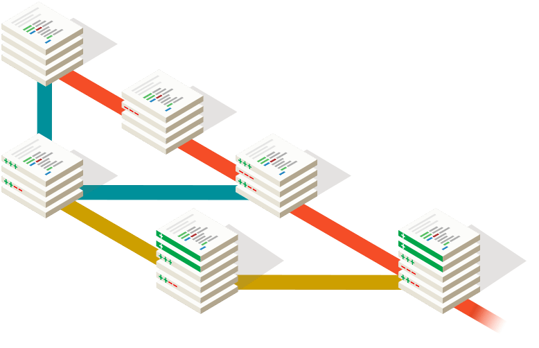

Sistema de control de versiones

## ¿Qué es un sistema de control de versiones?

Un control de versiones es un sistema que registra los cambios realizados en un archivos a lo largo del tiempo, permitiendo recuperar cualquier versión trabajada.

Git almacena y maneja información como conjunto de copias instantáneas de un sistema de archivos, como archivos miniatura, que permiten guardar una referencia en ellos. Además, la mayoría de las operaciones en Git se hacen con archivos y recursos locales, por ello evita el problema de la velocidad de red. Finalmente, su integridad radica en la suma de comprobaciones antes de ser almacenado, y la identificación de cada cambio.

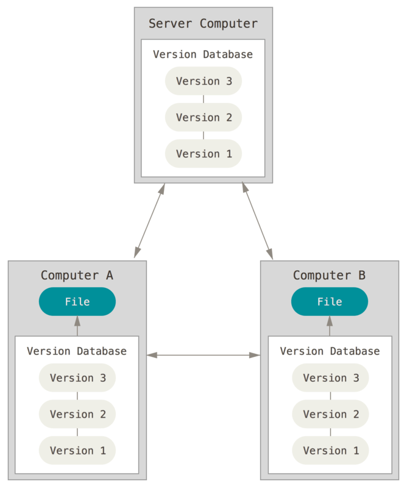

### Definiciones de Git

- **Repositorio**, es la principal unidad de Git. Este será el proyecto que contiene directorios, archivos y además permite *trackear* las diferentes versiones y cambios.
- **Branch**/**rama**, son las versiones paralelas del repositorio. Por defecto, los repositorios tienen una rama principal llamada **Main**. Las ramas posibilitan contar con diferentes versiones del repositorio así como el trabajo ordenado y en paralelo. Por ello, se pueden usar varias *ramas* para editar el contenido de *Main* separadamente.
- **Commit**, refiere a los conjunto de cambios en los archivos/directorios del proyecto. Estos son parte de una rama, podríamos entenderlos como *fotos instantáneas* del estado actual de los archivos en el repositorio, brindandonos un punto específico de la historia del proyecto. Cada *commit* incluye un mensaje descriptivo que ayuda a entender qué cambios se han hecho y por qué. Además, se identifican con un **Hash** como *número de identificación única*. Su característica principal, es que permiten rastrear, revertir y colaborar en los cambios del proyecto de manera eficiente.
- **Pull request** (solicitud de extracción), es una función que facilita la revisión y fusión de cambios de una rama a otra. Cuando se completan cambios en una rama (generalmente una en particular o una de solución de errores), se puede crear un *pull request* para solicitar que estos cambios se fusionen en la rama principal (como main o develop). Además, permite que otros colaboradores del proyecto revisen el código, discutan sobre las modificaciones, sugieran mejoras y aprueben o rechacen la fusión. Es una herramienta esencial para la colaboración en equipo y que se mantenga la calidad del código.
- **Remote** o repositorio remoto, es una versión del proyecto alojada en un servidor o en la nube, como GitHub, [GitLab](https://gitlab.com/)[^2] u otro servicio de alojamiento de repositorios. Además permite que múltiples usuarios colaboren en el mismo proyecto, facilitando la sincronización de cambios entre los diferentes entornos de trabajo.
- **Local**, es la versión del repositorio alojada en la computadora local del desarrollador o colaborador. Al *clonar* un repositorio remoto en tu máquina local, estás creando una copia exacta del proyecto. Posteriormente, podrás realizar cambios, *commits* y luego *subir* esos cambios de vuelta al repositorio remoto para que otros colaboradores puedan verlos y trabajar con ellos. De igual manera, podrás *recuperar* cambios realizados por otros en el repositorio remoto y sincronizarlos con tu copia local. El *remote* se gestiona por medio de URLs y se referencia mediante nombres cortos. Por defecto, el primer repositorio remoto se llama **origin**. Puedes agregar, eliminar y gestionar múltiples *remotes* en un solo repositorio local.
- **Readme**, es un archivo de texto (generalmente *README.md*, si fue escrito en [Markdown](https://www.markdownguide.org/)[^3]), donde se proporciona una descripción general del proyecto. Es uno de los primeros archivos que se ve al visitar un repositorio, especialmente en plataformas de alojamiento de repositorios. Este suele contener información útil como la descripción del proyecto, instrucciones sobre instalación y configuración, directrices sobre cómo contribuir, tipos de licencia, información de contacto, etc. Un buen README mejorará la accesibilidad y comprensión del proyecto.

### Flujo de trabajo básico en Git

- Hay dos maneras de crear un repositorio de Git
  - Puedes importar un directorio en Git.
  - Puedes clonar un repositorio existente Git.
- Modificas una serie de archivos en tu directorio de trabajo.
- Luego de modificados los archivos, debes prepararlos, añadiéndolos a tu área de preparación (indexados o *staging area*), indicándole a Git los próximos cambios a incluir.
- Confirmar los cambios, Git toma una instantánea de los archivos en **staging** área, y los almacena de manera permanente en el directorio de Git. Este será el estado final donde los cambios quedarán registrados.

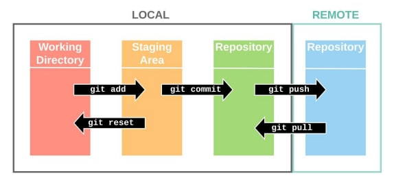

Directorio de trabajo, área de almacenamiento y directorio Git

##### Resumen de procedimientos de [Git](https://dev-to-uploads.s3.amazonaws.com/uploads/articles/n082uxea33j6zq3mca7u.png)

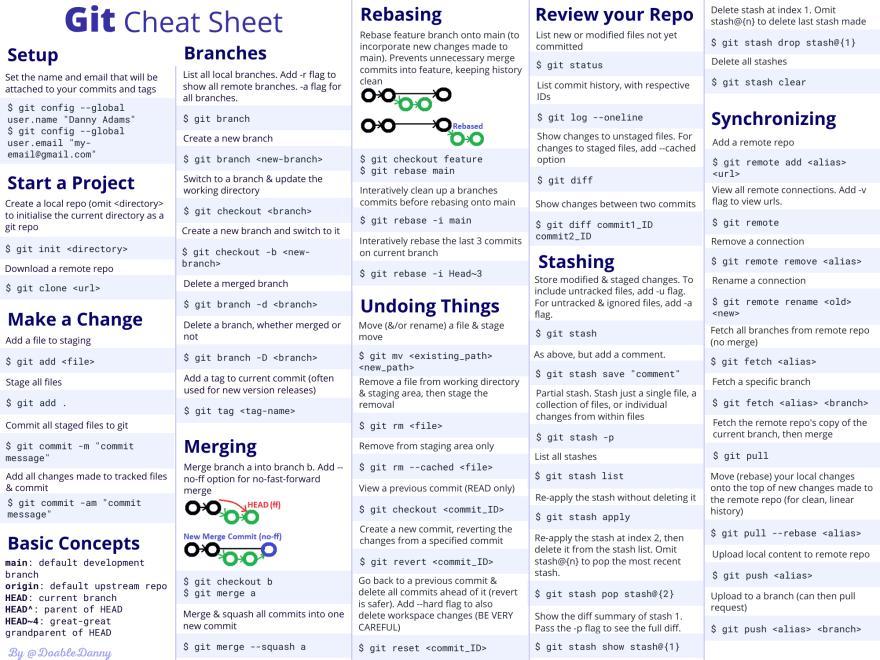

## Instalación de Git

Antes de empezar a utilizar Git, tienes que instalarlo en tu computadora. Incluso si ya está instalado, este es posiblemente un buen momento para actualizarlo a su última versión. Puedes instalarlo como un paquete, a partir de un archivo instalador o bajando el código fuente y compilándolo tú mismo. Las instrucciones para los tres sistemas operativos desde el siguiente [link](https://git-scm.com/book/es/v2/Inicio---Sobre-el-Control-de-Versiones-Instalaci%C3%B3n-de-Git). Se puede descargar desde:

- Descarga para [Windows](http://git-scm.com/download/win)
- Descarga para [Linux](http://git-scm.com/download/linux)
- Descarga para [Mac](http://git-scm.com/download/mac)

> Recomendación durante la instalación de Git, podrás seleccionar el editor de código de tu preferencia, en mi caso seleccioné VS Code porque lo tengo instalado, y me resulta cómodo.

[figure not shown]

Selección de editor de código

Continuar haciendo click en **Next** o **Continuar**, dejando las configuraciones que vienen de forma estándar hasta que aparezca la opción **Instalar** o **Install**, esperar a que finalice el proceso de instalación.

[figure not shown]

Final de instalación, el número de versión puede no ser el que figura en la imagen.

# ¿Qué es GitHub?

GitHub es un proveedor de alojamiento para repositorios Git, permitiendo proyectos de código abierto, seguimiento de fallos, revisión de código, etc. No es parte directa de Git, pero si es totalmente compatible y útil su uso en conjunto, para facilitar el trabajo colaborativo. Facilita el trabajo de compartir y colaborar entre diferentes miembros de un mismo proyecto.

### Acciones principales de interacción en GitHub

- **Crear** un repositorio o **clonar** uno existente. Los repositorios serán los lugares donde se alojan tus proyectos.
- **Bifurcación**: El proceso de copiar el código de otra persona del repositorio para modificarlo.
- **Pull**: Cuando haya terminado de hacer cambios en el código de otra persona, puede compartirlos con el propietario original a través de una *pull request*.
- **Fusión**: Los propietarios pueden añadir nuevos cambios a sus proyectos a través de una fusión, y dar crédito a los contribuyentes que los han sugerido.

### Integración git y GitHub

[figure not shown]

Integración Git y GitHub

Para que se puedan integrar Git con Github sigue los siguientes pasos, luego de la Instalación de Git.

1. Crear un usuario o iniciar sesión en [Github](https://github.com/), existe opción gratuita además de opciones pagas.
2. Crear o clonar un repositorio remoto de GitHub a tu cuenta (En el punto siguiente se verá como clonar y trabajar en git desde local). Al crear un repositorio se podrá compartir un repositorio ya creado en local.

| [GitHub: Creación y configuración de la cuenta](https://git-scm.com/book/es/v2/GitHub-Creaci%C3%B3n-y-configuraci%C3%B3n-de-la-cuenta) |
| --- |

3. **Pasos para trabajar en Git, clonar repositorios y modificar archivos**
- Abrir la **terminal GIT Bash** (Recordar, previamente, configurar los registros de usuario, mencionado en el ítem anterior)

[video not shown]

- Elegir ubicación para la carpeta donde va a alejarse el sitio en local:

> `cd ubicación-deseada`
- Clonar el repositorio en la PC:

> `git clone urldelrepositoriodegit`
- Ahora puedes trabajar en el archivo que desees del repositorio
- Una vez realizadas y guardadas las modificaciones, desde la **terminal** puedes observar el estado de las modificaciones:

> `git status`
- Ahora, debes añadir los archivos modificados que serán subidos/actualizdos en el repositorios:

> `git add * nombredelarchivo`[^4]
- Se debe comentar el **commit** sobre los cambios realizados:

> `git commit -m “breve descripcion de cambios”`
- **Importante**, siempre traer cambios hechos por otros usuarios al mismo tiempo:

> `git pull`
- Subir las modificaciones hechas en tu local al repositorio de GitHub:

> `git push`

# Ejercitación

### Ejercicios de creación y actualización de repositorios

> Esta ejercitación se recomienda realizarse en grupo, pues implicaría comprobar el trabajo en equipo en GitHub así como mejor entendimiento del sistema de control de versiones.

[figure not shown]

## Ejercicio 3

   > * Materia  
   > * Nombre de equipo  
   > * Participantes  
   > * Nombre-Estudiante-creador-del-archivo
3. Comprobar de nuevo el estado del repositorio.
4. Añadir el fichero a la zona de intercambio temporal.
5. Volver a comprobar una vez más el estado del repositorio.

Solución

```bash
> git status
> cat > indice.txt
* Materia
* Nombre de equipo
* Participantes
* Nombre-Estudiante-creador-del-archivo
Ctrl+D
> git status
> git add indice.txt
> git status
```

## Ejercicio 4

Realizar un commit de los últimos cambios con el mensaje “Archivo de estudiante-nombre al repositorio-del-grupo.” y ver el estado del repositorio.

Solución

```bash
> git commit -m “Archivo de estudiante-nombre al repositorio-del-grupo.”
> git status
```

## Ejercicio 5

1. Subir al repositorio grupal el archivo txt de cada estudiante. Recordar siempre primero hacer **pull**, para evitar conflictos entre versiones.
2. Mostrar los cambios con respecto a la última versión guardada en el repositorio.

   Al finalizar la ejercitación en el repositorio **remote** debería haber tantos archivos de textos como estudiantes en el grupo.

Solución

```bash
> git pull
> git push
> git status
```

1. Puedes encontrar un manual sobre ese sistema en https://git-scm.com/book/es/v2.
2. Puedes acceder a tutoriales de GitLab en: https://docs.gitlab.com/ee/user/.
3. Markdown es un lenguaje de marcado utilizado para definir archivos **.md**. Un tutorial en español: https://markdown.es/, también puedes acceder a más información en https://www.markdownguide.org/basic-syntax/.
4. Cuando se añaden archivos a *remote*, existen diferentes opciones de agregado, presento la opción **add *** porque serán ignorados los archivos que se inicien con ’**.’**, que son generalmente archivos ocultos, y permitirá el agregado de una carpeta completa o subdirectorios. Asimismo, más información sobre este paso en: https://git-scm.com/docs/git-add/es.
5. Comandos para **Git Bash** en Windows

   pwd: nos muestra la carpeta actual en la que nos encontramos. mkdir: nos permite crear carpetas, `mkdir NuevaCarpeta` touch: nos permite crear archivos nuevos `touch NuevoArchivo.txt` cat: nos permite ver el contenido de un archivo `cat NuevoArchivo.txt` `cat > nuevoarchivo.txt #añado el contenido necesario` y finalizo la creación con Ctrl+D cd: nos permite cambiarnos de carpeta, `cd NuevaCarpeta.` cd .. : nos permite regresar al directorio o carpeta anterior. cd o cd ~: nos lleva a la ruta del usuario. cd /c: nos vamos al disco C:/. cd -: nos lleva directamente al ultimo directorio visitado. ls: nos permite ver los archivos de la carpeta donde estamos actualmente. ls -l: Ver todos los archivos como una lista en donde incluye el usuario, grupo, permisos sobre el archivo, tamaño, fecha y hora de creación. ls -lh: Muestra la misma información que ls-l pero con unidades de tamaño, es decir, kb o mb. ls-R: muestra el contenido de todos los sudirectorios de forma recursiva. ls -S Ordena los resultados por tamaño de archivo. rm: Nos permite borrar un archivo o carpeta.`rm NuevoArchivo.txt` rmdir “nombre del directorio”/: borrar un directorio: Solo funciona con directorios vacíos. rm -r ‘nombre de la carpeta’ :me permite eliminar la carpeta y los archivos dentro de ella de forma recursiva. cp “nombre del archivo que quremos copiar” “nombre del directorio a donde lo queremos copiar”: nos permite copiar un archivo. mv “el directorio de donde queremos mover/el nombre del archivo” “el directorio hacia donde lo queremos mover”: nos permite mover un archivo. clear: nos permite limpiar la pantalla. history: ver los últimos comandos que ejecutamos y un número especial con el que podemos volver a repetir el comando.
6. Más información sobre Invitar colaboradores en: [https://docs.github.com/es/~inviting-collaborators-to-a-personal-repository](https://docs.github.com/es/account-and-profile/setting-up-and-managing-your-personal-account-on-github/managing-access-to-your-personal-repositories/inviting-collaborators-to-a-personal-repository).